# Heart Disease Analysis

Arjun Sonani

10/14/2021

# Heart Disease Analysis

This case study is about the analysis of the heart diseases. To get the data-set click [HERE](https://archive.ics.uci.edu/ml/datasets/heart+disease).

## Attributes about the data-set:

- age: age in years *sex: sex (1 = male; 0 = female)* cp: chest pain type – Value 0: typical angina – Value 1: atypical angina – Value 2: non-anginal pain – Value 3: asymptomatic *trestbps: resting blood pressure (in mm Hg on admission to the hospital)* chol: serum cholestoral in mg/dl *fbs: (fasting blood sugar > 120 mg/dl) (1 = true; 0 = false)* restecg: resting electrocardiographic results – Value 0: normal – Value 1: having ST-T wave abnormality (T wave inversions and/or ST elevation or depression of > 0.05 mV) – Value 2: showing probable or definite left ventricular hypertrophy by Estes’ criteria *thalach: maximum heart rate achieved* exang: exercise induced angina (1 = yes; 0 = no) *oldpeak: ST depression induced by exercise relative to rest* slope: the slope of the peak exercise ST segment – Value 1: upsloping – Value 2: flat – Value 3: downsloping *ca: number of major vessels (0-3) colored by flourosopy* thal: 3 = normal; 6 = fixed defect; 7 = reversable defect *num: diagnosis of heart disease (angiographic disease status) – Value 0: < 50% diameter narrowing – Value 1: > 50% diameter narrowing (in any major vessel: attributes 59 through 68 are vessels)

So, let us start by loading important libraries and the data-set:

```r
library(tidyverse)
```

```r
library(corrplot)
library(ggplot2)
data <- read.csv("heart.csv")
```

## Data Transformation:

```r
data2 <- data %>%
  mutate(sex = if_else(sex == 1, "MALE", "FEMALE"),
         fbs = if_else(fbs == 1, ">120", "<=120"),
         exang = if_else(exang == 1, "YES", "NO"),
         cp = if_else(cp == 1, "ATYPICAL ANGINA",
                      if_else(cp == 2, "NON-ANGINAL PAIN", "ASYMPTOMATIC")),
         restecg = if_else(restecg == 0, "NORMAL",
                           if_else(restecg == 1, "ABNORMALITY", "PROBABLE OR DEFINITE")),
         slope = as.factor(slope),
         ca = as.factor(ca),
         thal = as.factor(thal),
         target = if_else(target == 1, "YES", "NO"),
         ) %>%
  mutate_if(is.character, as.factor) %>%
  dplyr::select(target, sex, fbs, exang, cp, restecg, slope, ca, thal, everything())
```

## Data Visualization:

### Bar Plots:

*The Chart clearly shows that there are more amount of people suffering from some sort of heart diseases.

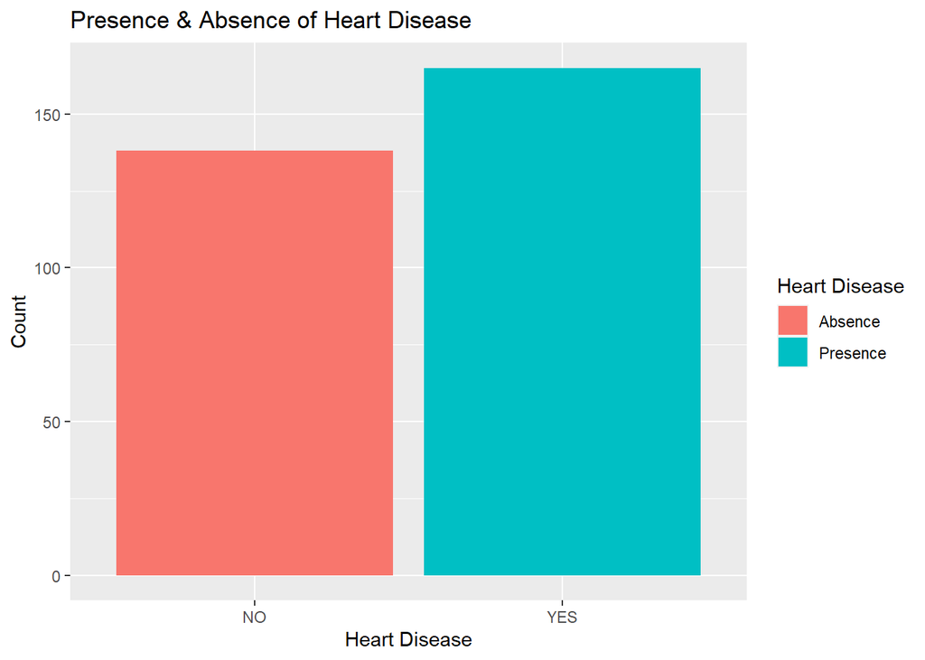

```r
ggplot(data2, aes(x=target,fill=target))+
  geom_bar()+
  xlab("Heart Disease")+
  ylab("Count")+
  ggtitle("Presence & Absence of Heart Disease")+
  scale_fill_discrete(name = "Heart Disease", label = c("Absence", "Presence"))
```

*Here we have a chart of the age group which is the part of the data.* We can also see that major population of the data lies between age range of 55 to 60. (Here the elements from the age column in grouped and then the groups were counted; also the filter is put where the threshold is set to be 10 which means if any group with less then 10 instances will not be displayed in the chart. )

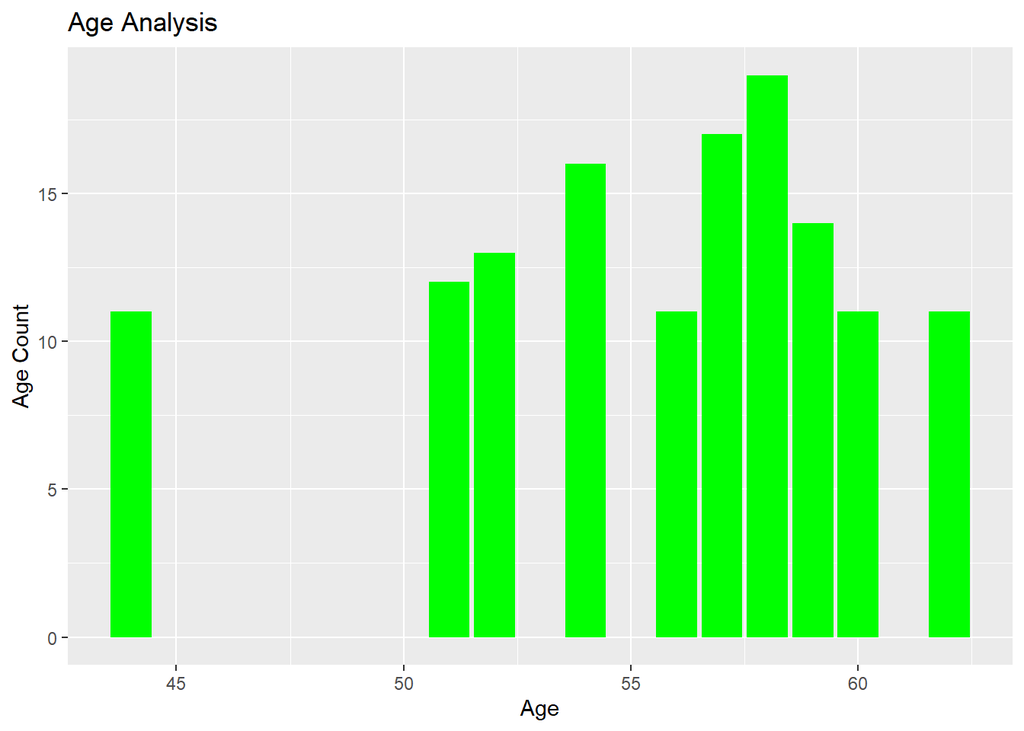

```r
data2 %>%
  group_by(ï..age) %>%
  count()%>%
  filter(n>10)%>%
  ggplot()+
  geom_col(aes(ï..age, n), fill = "green")+
  ggtitle("Age Analysis")+
  xlab("Age")+
  ylab("Age Count")
```

### Box Plots:

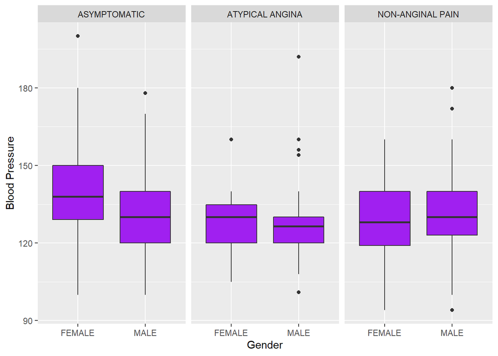

```r
data2 %>%
  ggplot(aes(x=sex, y=trestbps))+
  geom_boxplot(fill = "purple")+
  xlab("Gender")+
  ylab("Blood Pressure")+
  facet_grid(~cp)
```

*In the following box plot we can understand that the cholesterol levels of the patients measured on admission to the hospital.* We can say that in all the three chest pain types females are having higher cholesterol levels than males.

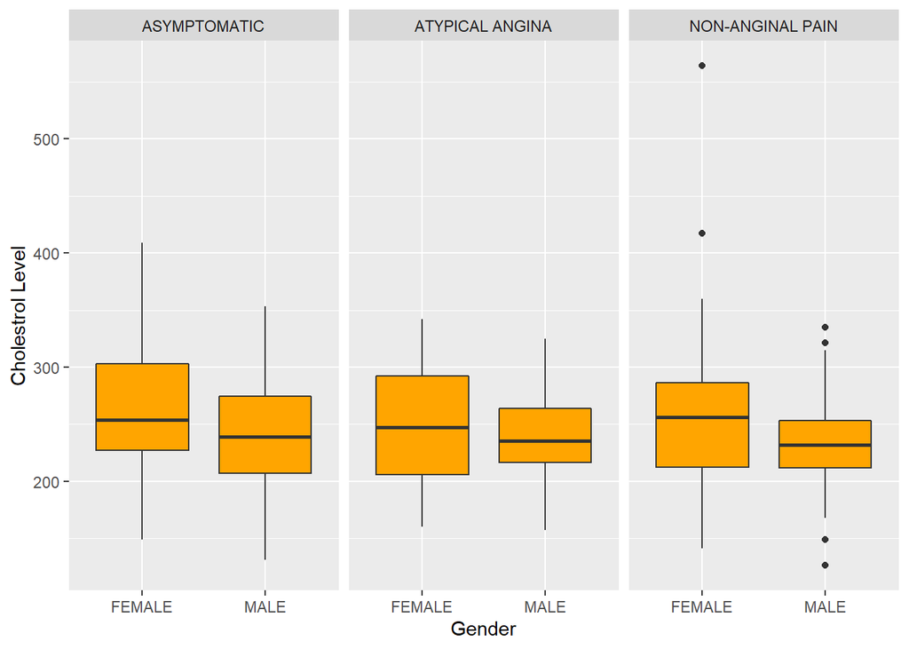

```r
data2 %>%
  ggplot(aes(x=sex, y=chol))+
  geom_boxplot(fill = "orange")+
  xlab("Gender")+
  ylab("Cholestrol Level")+
  facet_grid(~cp)
```

### Correlation:

*By having a glance over the correlation chart we can interpret few thing like: - Age and blood pressure are slightly correlated. - Age and cholesterol are slightly correlated. - Age and thalach(max. heart rate achieved) are negatively correlated.

```r
library(corrplot)
library(ggplot2)

cor_heart <- cor(data2[, 10:14])
cor_heart
```

```
##              ï..age    trestbps         chol      thalach     oldpeak
## ï..age    1.0000000  0.27935091  0.213677957 -0.398521938  0.21001257
## trestbps  0.2793509  1.00000000  0.123174207 -0.046697728  0.19321647
## chol      0.2136780  0.12317421  1.000000000 -0.009939839  0.05395192
## thalach  -0.3985219 -0.04669773 -0.009939839  1.000000000 -0.34418695
## oldpeak   0.2100126  0.19321647  0.053951920 -0.344186948  1.00000000
```

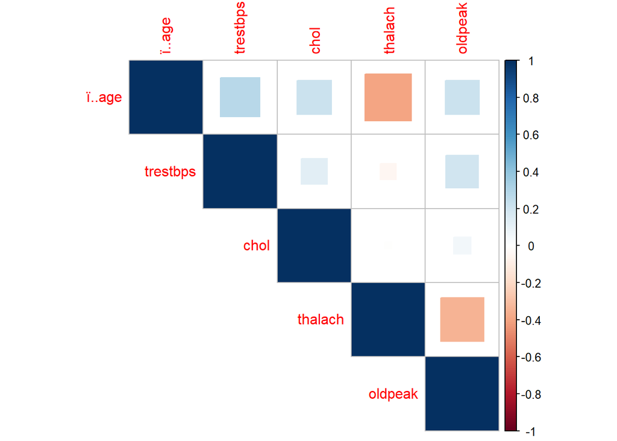

```r
corrplot(cor_heart, method = "square", type="upper")
```